# Part 4 lectures and exercises

The following set of commands is for my computer only

```r
# I'm not sure why I need this, so I'm commenting it out.
# setInternet2(use = FALSE)
# install.packages("knitr",repos="http://rweb.quant.ku.edu/cran/")
library("knitr")
```

## compare the formats

I’m going to use the term “longitudinal” data to designate data sets where a patient is measured at multiple different time points. This encompasses certain other data sets, such as from a crossover, pre-test/post-test, repeated measures, and split plot.

Don’t worry about the technical distinctions among these terms. The important thing to know for now is that longitudinal data represents one of the biggest challenges in data management and we will spend most of today discussing these challenges.

Longitudinal data usually come in of two specific formats. The first is the short and fat format and the second is the tall and thin format. Open these two webpages in Internet explorer to see the difference.

–> http://www.statsci.org/data/oz/ctsibrm.txt

–> http://www.statsci.org/data/oz/ctsibuni.txt

A description of the context for these files is at

–> http://www.statsci.org/data/oz/ctsib.html

The short and fat format has one row per patient and each successive patient encounter is strung out horizontally.

The tall and thin format has one row per patient encounter and therefore multiple rows per patient.

Both formats have advantages and disadvantages, and you need to know how to create a longitudinal file in either format and how to transform from one format to another.

Short and fat advantages:

1. easy to compute change scores
2. easy to examine correlations over time
3. easy to insure consistency of demographic data

Short and fat disadvantages:

1. hard to read because of the excessive need to scroll left and right

Tall and thin advantages:

1. easy to plot longitudinal trends
2. less need for missing value codes
3. easy to read because most scrolling is up and down

Tall and thin disadvantages

1. hard to maintain consistency of demographic variables

## Converting from short and fat to tall and thin

Here is a data set on termite survival. It is probably a bit of a stretch to call this longitudinal data, but it still is useful for illustrating how to convert longitudinal data.

The data is embedded in the description of the file. So you need to strip away the description from the data. It helps to import the data as entire lines, and you do this by specifying a separator character that is not found anywhere in the file.

```r
fi <- "http://lib.stat.cmu.edu/DASL/Datafiles/Termites.html"
te.tst <- read.table(file=fi,sep="~")
te.tst[1:40,]
```

```
##  [1] <TITLE>Termites Datafile</TITLE>
##  [2] <hr size=2><center><table border=1 cellpadding=0 cellspacing=0><tr><td align=center><table border=1 cellpadding=1 cellspacing=0><tr><td><A HREF=../DataArchive.html><IMG SRC=../InlineImages/mainmenu.gif alt=Go to Main Menu></a></td></tr></table></td><td align=center><table border=1 cellpaddin…
##  [3] <B><DT>Datafile Name:</B>   Termites
##  [4] <B><DT>Datafile Subjects:</B>   <dsubjects>
##  [5] <A HREF=/cgi-bin/dasl.cgi?query=Agriculture&submit=Search&metaname=dsubjects&sort=swishrank>Agriculture</A>
##  [6] </dsubjects>
##  [7] <B><DT>Story Names:</B>
##  [8] <A HREF=../Stories/ResinsRidTermitesfromTrees.html>Resins Rid Termites from Trees</A>
##  [9] <B><DT>Reference:</B>   This data is distributed with the software package, Data Desk¨.  Data Description, Inc. (1993). <I>Data Desk¨.</I> Ithaca, NY: Data Description, Inc.
## [10] <B><DT>Authorization:</B>   Not Sure Yet
## [11] <B><DT>Description:</B>   The data collected here are from an experiment to investigate the effects of certain tree resins on termites.  A resin derived from the bark of tropical trees is dissolved in a solvent and placed on filter paper in different concentrations (5mg and 10mg).  For each …
## [12] <B><DT>Number of cases:</B>   12
## [13] <B><DT>Variable Names:</B>
## [14] <OL>
## [15] <LI>dish:   dish number
```

[output cut: 26 more lines]

```r
tail(te.tst)
```

```
##                                        V1
## 47 4\t10\t25\t24\t¥\t14\t10\t7\t4\t3\t¥\t3\t2\t2\t2\t1\t0
## 48  5\t10\t25\t24\t¥\t16\t9\t6\t5\t1\t¥\t0\t0\t0\t0\t0\t0
## 49   6\t10\t25\t24\t¥\t7\t3\t1\t1\t1\t¥\t0\t0\t0\t0\t0\t0
## 50   7\t10\t25\t18\t¥\t4\t3\t1\t1\t0\t¥\t0\t0\t0\t0\t0\t0
## 51  8\t10\t25\t21\t¥\t17\t9\t7\t7\t7\t¥\t5\t4\t3\t3\t3\t3
## 52                                 </PRE>
```

If you look at the first 40 lines, it is obvious that the data starts somewhere around line 35. and that every previous line (and the very last line) start with an html tag. The comment argument allows us to skip any line starting with an html tag.

Also note the prevalence of “” values. These show that the data itself is a tab-delimited file.

This is one of those cute R tricks that I tend to like, but if you prefer, you could just cut-and-paste just the lines that you want from the webpage and store the results in a text editor like notepad.

```r
te <- read.table(file=fi,header=TRUE,comment="<")
head(te)
```

```
##   dish dose day1 day2 day3 day4 day5 day6 day7 day8 day9 day10 day11 day12
## 1    1    5   25   24    ¥   22   18   17   15   14    ¥    13    13    12
## 2    2    5   25   25    ¥   25   21   20   17   15    ¥    15    15    12
## 3    3    5   25   25    ¥   24   23   21   20   19    ¥    16    13    13
## 4    4    5   25   25    ¥   25   24   22   22   21    ¥    20    18    13
## 5    5    5   25   25    ¥   22   19   18   17   14    ¥    13    11    11
## 6    6    5   25   25    ¥   23   20   17   16   15    ¥    15    13    11
##   day13 day14 day15
## 1    11    11    11
## 2    11    11    11
## 3    13    13    12
## 4    13    13    12
## 5     8     8     5
## 6    11    10     9
```

```r
tail(te)
```

```
##    dish dose day1 day2 day3 day4 day5 day6 day7 day8 day9 day10 day11
## 11    3   10   25   24    ¥   12    6    5    4    2    ¥     2     1
## 12    4   10   25   24    ¥   14   10    7    4    3    ¥     3     2
## 13    5   10   25   24    ¥   16    9    6    5    1    ¥     0     0
## 14    6   10   25   24    ¥    7    3    1    1    1    ¥     0     0
## 15    7   10   25   18    ¥    4    3    1    1    0    ¥     0     0
## 16    8   10   25   21    ¥   17    9    7    7    7    ¥     5     4
##    day12 day13 day14 day15
## 11     1     1     1     1
## 12     2     2     1     0
## 13     0     0     0     0
## 14     0     0     0     0
## 15     0     0     0     0
## 16     3     3     3     3
```

```r
summary(te)
```

```
##       dish           dose           day1         day2       day3
##  Min.   :1.00   Min.   : 5.0   Min.   :25   Min.   :18.00   ¥:16
##  1st Qu.:2.75   1st Qu.: 5.0   1st Qu.:25   1st Qu.:24.00
##  Median :4.50   Median : 7.5   Median :25   Median :24.50
##  Mean   :4.50   Mean   : 7.5   Mean   :25   Mean   :23.94
##  3rd Qu.:6.25   3rd Qu.:10.0   3rd Qu.:25   3rd Qu.:25.00
##  Max.   :8.00   Max.   :10.0   Max.   :25   Max.   :25.00
##       day4            day5            day6            day7
##  Min.   : 4.00   Min.   : 3.00   Min.   : 1.00   Min.   : 1.00
##  1st Qu.:15.50   1st Qu.: 9.00   1st Qu.: 6.75   1st Qu.: 4.75
##  Median :22.50   Median :19.00   Median :17.00   Median :16.00
##  Mean   :19.00   Mean   :15.56   Mean   :13.81   Mean   :12.62
##  3rd Qu.:23.25   3rd Qu.:21.25   3rd Qu.:20.25   3rd Qu.:18.25
##  Max.   :25.00   Max.   :24.00   Max.   :22.00   Max.   :22.00
##       day8       day9       day10           day11           day12
##  Min.   : 0.00   ¥:16   Min.   : 0.00   Min.   : 0.00   Min.   : 0.000
##  1st Qu.: 2.75          1st Qu.: 2.75   1st Qu.: 1.75   1st Qu.: 1.750
##  Median :14.00          Median :13.00   Median :12.50   Median :11.000
##  Mean   :11.31          Mean   :10.31   Mean   : 9.50   Mean   : 8.375
##  3rd Qu.:18.00          3rd Qu.:16.00   3rd Qu.:15.00   3rd Qu.:12.250
##  Max.   :21.00          Max.   :20.00   Max.   :18.00   Max.   :18.000
##      day13            day14          day15
##  Min.   : 0.000   Min.   : 0.0   Min.   : 0.000
##  1st Qu.: 1.750   1st Qu.: 1.0   1st Qu.: 0.750
##  Median :10.000   Median : 9.0   Median : 7.500
##  Mean   : 7.812   Mean   : 7.5   Mean   : 6.812
##  3rd Qu.:11.500   3rd Qu.:11.5   3rd Qu.:11.250
##  Max.   :17.000   Max.   :17.0   Max.   :16.000
```

We need to re-organize this data before we can plot it.

```r
sb01 <- te[,c("dish","dose","day1")]
names(sb01)[3] <- "count.living"
sb01$day <- 1
sb01
```

```
##    dish dose count.living day
## 1     1    5           25   1
## 2     2    5           25   1
## 3     3    5           25   1
## 4     4    5           25   1
## 5     5    5           25   1
## 6     6    5           25   1
## 7     7    5           25   1
## 8     8    5           25   1
## 9     1   10           25   1
## 10    2   10           25   1
## 11    3   10           25   1
## 12    4   10           25   1
## 13    5   10           25   1
## 14    6   10           25   1
## 15    7   10           25   1
## 16    8   10           25   1
```

```r
sb02 <- te[,c("dish","dose","day2")]
names(sb02)[3] <- "count.living"
sb02$day <- 2
sb02
```

```
##    dish dose count.living day
## 1     1    5           24   2
## 2     2    5           25   2
## 3     3    5           25   2
## 4     4    5           25   2
## 5     5    5           25   2
## 6     6    5           25   2
## 7     7    5           25   2
## 8     8    5           25   2
## 9     1   10           24   2
## 10    2   10           25   2
## 11    3   10           24   2
## 12    4   10           24   2
## 13    5   10           24   2
## 14    6   10           24   2
## 15    7   10           18   2
## 16    8   10           21   2
```

```r
sb04 <- te[,c("dish","dose","day4")]
names(sb04)[3] <- "count.living"
sb04$day <- 4

sb05 <- te[,c("dish","dose","day5")]
names(sb05)[3] <- "count.living"
sb05$day <- 5

sb06 <- te[,c("dish","dose","day6")]
names(sb06)[3] <- "count.living"
sb06$day <- 6

sb07 <- te[,c("dish","dose","day7")]
names(sb07)[3] <- "count.living"
sb07$day <- 7

sb08 <- te[,c("dish","dose","day8")]
names(sb08)[3] <- "count.living"
sb08$day <- 8

sb10 <- te[,c("dish","dose","day10")]
names(sb10)[3] <- "count.living"
sb10$day <- 10

sb11 <- te[,c("dish","dose","day11")]
names(sb11)[3] <- "count.living"
sb11$day <- 11

sb12 <- te[,c("dish","dose","day12")]
names(sb12)[3] <- "count.living"
sb12$day <- 12

sb14 <- te[,c("dish","dose","day14")]
names(sb14)[3] <- "count.living"
sb14$day <- 14

sb15 <- te[,c("dish","dose","day15")]
names(sb15)[3] <- "count.living"
sb15$day <- 15

tea <- rbind(sb01,sb02,sb04,sb05,sb06,sb07,sb08,
                 sb10,sb11,sb12,sb14,sb15)
head(tea)
```

```
##   dish dose count.living day
## 1    1    5           25   1
## 2    2    5           25   1
## 3    3    5           25   1
## 4    4    5           25   1
## 5    5    5           25   1
## 6    6    5           25   1
```

```r
tail(tea)
```

```
##     dish dose count.living day
## 187    3   10            1  15
## 188    4   10            0  15
## 189    5   10            0  15
## 190    6   10            0  15
## 191    7   10            0  15
## 192    8   10            3  15
```

That’s a bit tedious, and a clever R programmer could find a way to use looping structures like “for” to shorten the code. But there is a specialized library, reshape2, that makes things even easier.

```r
library("reshape2")
teb <- melt(te,id.vars=c("dish","dose"))
head(teb)
```

```
##   dish dose variable value
## 1    1    5     day1    25
## 2    2    5     day1    25
## 3    3    5     day1    25
## 4    4    5     day1    25
## 5    5    5     day1    25
## 6    6    5     day1    25
```

```r
tail(teb)
```

```
##     dish dose variable value
## 235    3   10    day15     1
## 236    4   10    day15     0
## 237    5   10    day15     0
## 238    6   10    day15     0
## 239    7   10    day15     0
## 240    8   10    day15     3
```

```r
tec <- melt(te[,c(-5,-11)],id.vars=c("dish","dose"))
head(tec)
```

```
##   dish dose variable value
## 1    1    5     day1    25
## 2    2    5     day1    25
## 3    3    5     day1    25
## 4    4    5     day1    25
## 5    5    5     day1    25
## 6    6    5     day1    25
```

```r
tail(tec)
```

```
##     dish dose variable value
## 203    3   10    day15     1
## 204    4   10    day15     0
## 205    5   10    day15     0
## 206    6   10    day15     0
## 207    7   10    day15     0
## 208    8   10    day15     3
```

We’re not done quite yet. The day of the week is hidden in the variable called “variable” and we need to keep only the fourth (and maybe fifth) characters.

```r
substr(tec$variable,4,5)
```

```
##   [1] "1"  "1"  "1"  "1"  "1"  "1"  "1"  "1"  "1"  "1"  "1"  "1"  "1"  "1"
##  [15] "1"  "1"  "2"  "2"  "2"  "2"  "2"  "2"  "2"  "2"  "2"  "2"  "2"  "2"
##  [29] "2"  "2"  "2"  "2"  "4"  "4"  "4"  "4"  "4"  "4"  "4"  "4"  "4"  "4"
##  [43] "4"  "4"  "4"  "4"  "4"  "4"  "5"  "5"  "5"  "5"  "5"  "5"  "5"  "5"
##  [57] "5"  "5"  "5"  "5"  "5"  "5"  "5"  "5"  "6"  "6"  "6"  "6"  "6"  "6"
##  [71] "6"  "6"  "6"  "6"  "6"  "6"  "6"  "6"  "6"  "6"  "7"  "7"  "7"  "7"
##  [85] "7"  "7"  "7"  "7"  "7"  "7"  "7"  "7"  "7"  "7"  "7"  "7"  "8"  "8"
##  [99] "8"  "8"  "8"  "8"  "8"  "8"  "8"  "8"  "8"  "8"  "8"  "8"  "8"  "8"
## [113] "10" "10" "10" "10" "10" "10" "10" "10" "10" "10" "10" "10" "10" "10"
## [127] "10" "10" "11" "11" "11" "11" "11" "11" "11" "11" "11" "11" "11" "11"
## [141] "11" "11" "11" "11" "12" "12" "12" "12" "12" "12" "12" "12" "12" "12"
## [155] "12" "12" "12" "12" "12" "12" "13" "13" "13" "13" "13" "13" "13" "13"
## [169] "13" "13" "13" "13" "13" "13" "13" "13" "14" "14" "14" "14" "14" "14"
## [183] "14" "14" "14" "14" "14" "14" "14" "14" "14" "14" "15" "15" "15" "15"
## [197] "15" "15" "15" "15" "15" "15" "15" "15" "15" "15" "15" "15"
```

Almost. We need to convert from character to numeric.

```r
tec$day <- as.numeric(substr(tec$variable,4,5))
head(tec)
```

```
##   dish dose variable value day
## 1    1    5     day1    25   1
## 2    2    5     day1    25   1
## 3    3    5     day1    25   1
## 4    4    5     day1    25   1
## 5    5    5     day1    25   1
## 6    6    5     day1    25   1
```

```r
tail(tec)
```

```
##     dish dose variable value day
## 203    3   10    day15     1  15
## 204    4   10    day15     0  15
## 205    5   10    day15     0  15
## 206    6   10    day15     0  15
## 207    7   10    day15     0  15
## 208    8   10    day15     3  15
```

I’m not too thrilled with the non-descriptive name, value, but I’m also too lazy here to change it or to drop the now unneeded column, variable.

Now to plot the data.

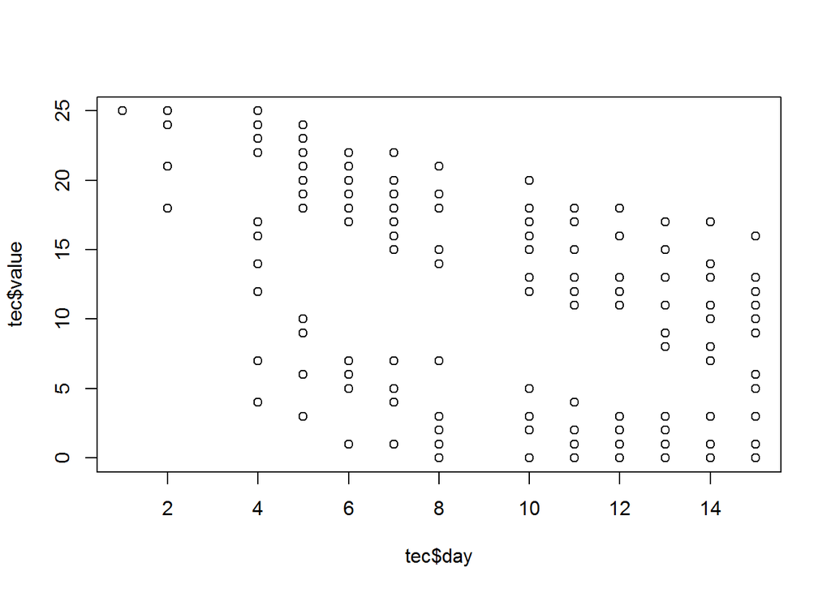

```r
plot(tec$day,tec$value)
```

Let’s connect the data for individual subjects.

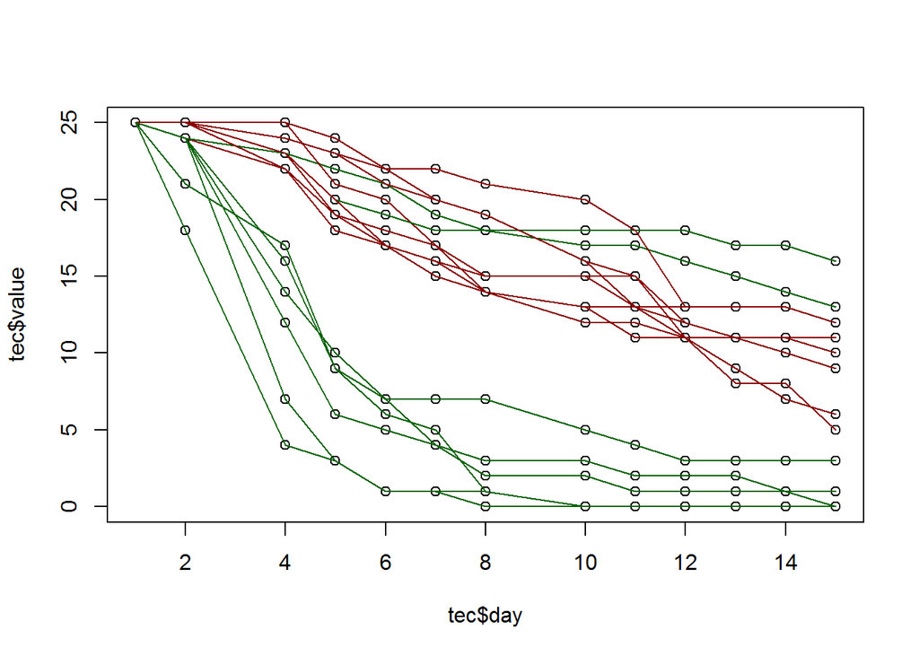

```r
plot(tec$day,tec$value)
for (i in 1:8) {
  sb <- tec$dish==i&tec$dose==5
  lines(tec$day[sb],tec$value[sb],col="darkred")
  sb <- tec$dish==i&tec$dose==10
  lines(tec$day[sb],tec$value[sb],col="darkgreen")
}
```

If you look at the graph, there are a couple of green lines, which represent dose=10, but which have mnay more alive at day 15 than even the dose=5 values. If you look at the original data set, these are rows 9 and 10, corresponding to the first two dishes in the dose=10 group. This may be okay, but you should check with the people who collected the data, if you can.

## A data set on depression after an earthquake (short and fat format)

This data set is described in –> http://www.statsci.org/data/general/lomaprie.html

```r
fn <- "http://www.statsci.org/data/general/lomaprie.txt"
qu <- read.table(fn,header=TRUE)
qu
```

```
##    Week0 Week3 Week6 Week9 Week12
## 1      6    10     8     4      6
## 2      2     4     8     5      6
## 3      2     4     8     5      6
## 4      4     5     8    10      7
## 5      4     7     9     7     12
## 6      5     7     9     7      7
## 7      2     9    11     8      8
## 8      6     9    11     8      8
## 9     13    10    11     8      9
## 10     7     3    11     8     11
## 11     7    12     8     8     11
## 12     7    10    11     9     11
## 13     9    10    13    10     11
## 14     9    11    12     6     12
## 15    11    11    12    19      7
## 16    11    12    12    12     19
## 17    12    12    12    13     14
## 18    12    12    13    13     15
## 19     7    12    13    13     15
## 20    13    10    13    14     15
## 21    13    14    11    15     16
## 22    13    14    14    17     16
## 23    13    14    15    11     18
## 24    14    14    15    20     14
## 25    15    17    16    21     19
```

## On your own

Convert this to a tall and thin format. Draw boxplots.

## A data set on energy consumption (short and fat format)

This data set is described at

–> http://www.statsci.org/data/general/energy.html

```r
fi <- "http://www.statsci.org/data/general/energy.txt"
en <- read.table(fi,header=TRUE)
head(en)
```

```
##   Subject Running Walking Cycling
## 1       1     1.4     1.1     0.7
## 2       2     1.5     1.2     0.8
## 3       3     1.8     1.3     0.7
## 4       4     1.7     1.3     0.8
## 5       5     1.6     0.7     0.1
## 6       6     1.5     1.2     0.7
```

```r
tail(en)
```

```
##   Subject Running Walking Cycling
## 3       3     1.8     1.3     0.7
## 4       4     1.7     1.3     0.8
## 5       5     1.6     0.7     0.1
## 6       6     1.5     1.2     0.7
## 7       7     1.7     1.1     0.4
## 8       8     2.0     1.3     0.6
```

## Converting from tall and thin to short and fat

Now let’s read in a tall and thin format and convert it to a short and wide format.

This data set is described at

–> http://www.statsci.org/data/general/cholest.html

```r
fi <- "http://www.statsci.org/data/general/cholestg.txt"
ch <- read.table(fi,header=TRUE)
head(ch)
```

```
##   patient group day cholest
## 1       1     1   2     270
## 2       2     1   2     236
## 3       3     1   2     210
## 4       4     1   2     142
## 5       5     1   2     280
## 6       6     1   2     272
```

```r
tail(ch)
```

```
##     patient group day cholest
## 109      53     2  NA     162
## 110      54     2  NA     182
## 111      55     2  NA     218
## 112      56     2  NA     170
## 113      57     2  NA     200
## 114      58     2  NA     176
```

```r
summary(ch)
```

```
##     patient          group            day            cholest
##  Min.   : 1.00   Min.   :1.000   Min.   : 2.000   Min.   :116.0
##  1st Qu.:10.00   1st Qu.:1.000   1st Qu.: 2.000   1st Qu.:188.0
##  Median :19.50   Median :1.000   Median : 4.000   Median :220.0
##  Mean   :22.13   Mean   :1.263   Mean   : 6.667   Mean   :224.5
##  3rd Qu.:29.75   3rd Qu.:2.000   3rd Qu.:14.000   3rd Qu.:256.0
##  Max.   :58.00   Max.   :2.000   Max.   :14.000   Max.   :360.0
##                                  NA's   :30       NA's   :9
```

The summary is not too helpful for the first three variables, so try the table command instead.

```r
table(ch$patient,useNA="always")
```

```
##
##    1    2    3    4    5    6    7    8    9   10   11   12   13   14   15
##    3    3    3    3    3    3    3    3    3    3    3    3    3    3    3
##   16   17   18   19   20   21   22   23   24   25   26   27   28   29   30
##    3    3    3    3    3    3    3    3    3    3    3    3    3    1    1
##   31   32   33   34   35   36   37   38   39   40   41   42   43   44   45
##    1    1    1    1    1    1    1    1    1    1    1    1    1    1    1
##   46   47   48   49   50   51   52   53   54   55   56   57   58 <NA>
##    1    1    1    1    1    1    1    1    1    1    1    1    1    0
```

```r
table(ch$group,useNA="always")
```

```
##
##    1    2 <NA>
##   84   30    0
```

```r
table(ch$day,useNA="always")
```

```
##
##    2    4   14 <NA>
##   28   28   28   30
```

It’s still a bit confusing. Why do the first 28 subjects have three measurements and the last 30 have only one measurement.

```r
table(ch$patient,ch$day,useNA="always")
```

```
##
##        2 4 14 <NA>
##   1    1 1  1    0
##   2    1 1  1    0
##   3    1 1  1    0
##   4    1 1  1    0
##   5    1 1  1    0
##   6    1 1  1    0
##   7    1 1  1    0
##   8    1 1  1    0
##   9    1 1  1    0
##   10   1 1  1    0
##   11   1 1  1    0
##   12   1 1  1    0
##   13   1 1  1    0
```

[output cut: 46 more lines]

```r
table(ch$group,ch$day,useNA="always")
```

```
##
##         2  4 14 <NA>
##   1    28 28 28    0
##   2     0  0  0   30
##   <NA>  0  0  0    0
```

Okay, now it’s a bit more clear. Each subject has measurements on three days (2,4,14) for group one, and measurements on an unspecified day (NA) for group 2.

Let’s look at the tedious and the faster way to convert from the tall and thin to the short and fat format.

The missing value for day is going to cause a lot of grief, and it is simpler here to change it to a special code, 99.

```r
ch$day[is.na(ch$day)] <- 99

sb02 <- ch[ch$day==2,c(1,4)]
names(sb02)[2] <- "cholest02"
head(sb02)
```

```
##   patient cholest02
## 1       1       270
## 2       2       236
## 3       3       210
## 4       4       142
## 5       5       280
## 6       6       272
```

```r
sb04 <- ch[ch$day==4,c(1,4)]
names(sb04)[2] <- "cholest04"
head(sb04)
```

```
##    patient cholest04
## 29       1       218
## 30       2       234
## 31       3       214
## 32       4       116
## 33       5       200
## 34       6       276
```

```r
sb14 <- ch[ch$day==14,c(1,4)]
names(sb14)[2] <- "cholest14"
head(sb14)
```

```
##    patient cholest14
## 57       1       156
## 58       2        NA
## 59       3       242
## 60       4        NA
## 61       5        NA
## 62       6       256
```

```r
sb99 <- ch[ch$day==99,c(1,4)]
names(sb99)[2] <- "cholest99"
head(sb99)
```

```
##    patient cholest99
## 85      29       196
## 86      30       232
## 87      31       200
## 88      32       242
## 89      33       206
## 90      34       178
```

```r
me1 <- merge(sb02,sb04,by="patient")
head(me1)
```

```
##   patient cholest02 cholest04
## 1       1       270       218
## 2       2       236       234
## 3       3       210       214
## 4       4       142       116
## 5       5       280       200
## 6       6       272       276
```

```r
tail(me1)
```

```
##    patient cholest02 cholest04
## 23      23       280       218
## 24      24       278       248
## 25      25       288       278
## 26      26       288       248
## 27      27       244       270
## 28      28       236       242
```

```r
me2 <- merge(me1,sb14,by="patient")
head(me2)
```

```
##   patient cholest02 cholest04 cholest14
## 1       1       270       218       156
## 2       2       236       234        NA
## 3       3       210       214       242
## 4       4       142       116        NA
## 5       5       280       200        NA
## 6       6       272       276       256
```

```r
tail(me2)
```

```
##    patient cholest02 cholest04 cholest14
## 23      23       280       218        NA
## 24      24       278       248       198
## 25      25       288       278        NA
## 26      26       288       248       256
## 27      27       244       270       280
## 28      28       236       242       204
```

```r
me3 <- merge(me2,sb99,by="patient")
head(me3)
```

```
## [1] patient   cholest02 cholest04 cholest14 cholest99
## <0 rows> (or 0-length row.names)
```

```r
tail(me3)
```

```
## [1] patient   cholest02 cholest04 cholest14 cholest99
## <0 rows> (or 0-length row.names)
```

Oops! What happened here is that no matches were found and the default in the merge function is to only include in the merge those rows that are found in both data sets. This is known as an inner join in database parlance. You can use the all.x and all.y arguments to use a left join, right join, or outer join instead.

```r
me3 <- merge(me2,sb99,by="patient",all.x=TRUE,all.y=TRUE)
head(me3)
```

```
##   patient cholest02 cholest04 cholest14 cholest99
## 1       1       270       218       156        NA
## 2       2       236       234        NA        NA
## 3       3       210       214       242        NA
## 4       4       142       116        NA        NA
## 5       5       280       200        NA        NA
## 6       6       272       276       256        NA
```

```r
tail(me3)
```

```
##    patient cholest02 cholest04 cholest14 cholest99
## 53      53        NA        NA        NA       162
## 54      54        NA        NA        NA       182
## 55      55        NA        NA        NA       218
## 56      56        NA        NA        NA       170
## 57      57        NA        NA        NA       200
## 58      58        NA        NA        NA       176
```

```r
ch1 <- melt(ch,id=c("patient","day","group"))
head(ch1)
```

```
##   patient day group variable value
## 1       1   2     1  cholest   270
## 2       2   2     1  cholest   236
## 3       3   2     1  cholest   210
## 4       4   2     1  cholest   142
## 5       5   2     1  cholest   280
## 6       6   2     1  cholest   272
```

```r
tail(ch1)
```

```
##     patient day group variable value
## 109      53  99     2  cholest   162
## 110      54  99     2  cholest   182
## 111      55  99     2  cholest   218
## 112      56  99     2  cholest   170
## 113      57  99     2  cholest   200
## 114      58  99     2  cholest   176
```

```r
ch2 <- dcast(ch1,patient+group~variable+day)
head(ch2)
```

```
##   patient group cholest_2 cholest_4 cholest_14 cholest_99
## 1       1     1       270       218        156         NA
## 2       2     1       236       234         NA         NA
## 3       3     1       210       214        242         NA
## 4       4     1       142       116         NA         NA
## 5       5     1       280       200         NA         NA
## 6       6     1       272       276        256         NA
```

```r
tail(ch2)
```

```
##    patient group cholest_2 cholest_4 cholest_14 cholest_99
## 53      53     2        NA        NA         NA        162
## 54      54     2        NA        NA         NA        182
## 55      55     2        NA        NA         NA        218
## 56      56     2        NA        NA         NA        170
## 57      57     2        NA        NA         NA        200
## 58      58     2        NA        NA         NA        176
```

```r
cor(ch2[,c("cholest_2","cholest_4","cholest_14")])
```

```
##            cholest_2 cholest_4 cholest_14
## cholest_2          1        NA         NA
## cholest_4         NA         1         NA
## cholest_14        NA        NA          1
```

Oops! The missing values hurt us here. Review the help file for cor.

```r
cor(ch2[,c("cholest_2","cholest_4","cholest_14")],use="p")
```

```
##            cholest_2 cholest_4 cholest_14
## cholest_2  1.0000000 0.6731814  0.3927710
## cholest_4  0.6731814 1.0000000  0.7120277
## cholest_14 0.3927710 0.7120277  1.0000000
```

## A data set on back pain with two matched control groups

This data set is described in –> http://www.statsci.org/data/oz/backpain.html

Subjexts were matched by age, height, and weight. How well were they matched?

```r
fn <- "http://www.statsci.org/data/oz/backpain.txt"
ma <- read.table(fn,header=TRUE)
ma <- ma[,1:6]
head(ma)
```

```
##   Subject Group Match Age Height Weight
## 1       1  Pain     1  22    180     74
## 2       2  Pain     3  17    182     65
## 3       3  Pain     2  17    182     70
## 4       4  Pain     8  32    175     83
## 5       5  Pain     7  50    167     60
## 6       6  Pain     4  32    181     71
```

```r
tail(ma)
```

```
##    Subject     Group Match Age Height Weight
## 28      28 Sedentary     4  31    178     68
## 29      29 Sedentary     3  18    183     63
## 30      30 Sedentary     1  21    185     75
## 31      31 Sedentary     6  38    178     75
## 32      32 Sedentary     9  47    186     74
## 33      33 Sedentary     7  49    167     73
```

## On your own

Convert this to a short and fat format. Let age1 represent the age of the subject in the pain group, age2 represent the matched subject in the nopain group, and age3 represent the matched subject in the sedentary group. Redefine height and weight similarly.

Plot age1 versus age2 and age1 versus age3 to evaluate how closely the subjects are matched on age. Repeat for height and weight.

## If there is extra time

Here is a very complex data set on stroke. –> http://www.statsci.org/data/oz/stroke.html

```
fi <- "http://www.statsci.org/data/oz/stroke.txt"
st <- read.table(fi,header=TRUE)
head(st)
tail(st)
```

Save everything

```r
save.image("part4.RData")
```

## There is no special assignment to be handed in today.

If you have extra time, work on your own data set.